# Stat_2021_b_4_multi

```python
import warnings
warnings.filterwarnings('ignore')
from matplotlib import pyplot as plt
%matplotlib inline
# 設定圖形大小; DPI越大圖越大
plt.rcParams["figure.dpi"] = 80
import seaborn as sns
import pandas as pd
import numpy as np
import scipy.stats as stats
import statsmodels.api as sm
import statsmodels.stats.api as sms
import statsmodels.formula.api as smf
import statsmodels.stats.multicomp as smm
import statsmodels.stats.outliers_influence as sso
import statsmodels
import math
import statistics
```

```python
def Outlier(SD):
    df = pd.DataFrame(SD,columns = ['SD'])
    filter = (df['SD'] < -2) | (df['SD'] > 2)
    outliers = df['SD'].loc[filter]
    ids = outliers.index
    ids = [n+1 for n in ids]

    print("Outliers by SD = \n")
    print(outliers)

    if len(ids)== 0:
        print("\nThere isnt any oulier.")
    else:
        print("\nSample", ids, "are outliers.")
```

```python
def Chi_Square_for_Normality(SD, N, a):
    m = np.mean(SD)
    s = np.std(SD)
    prob_bins = np.zeros((N + 1))
    z_bins = np.zeros((N + 1))
    z_bins[0] = -4
    z_bins[N] = 4
    for i in range(0, N+1):
        prob_bins[i] = i/N
    for j in range(1, N):
        z_bins[j] = m + stats.norm.isf(1 - prob_bins[j]) * s
    counts, bins = np.histogram(SD, bins=z_bins)
    nobs = counts.sum()
    prob_e = np.zeros((N))
    for i in range(1, N+1):
        prob_e[i - 1] = prob_bins[i] - prob_bins[i - 1]
    freq_e = nobs * prob_e
    freq_o = counts
    if np.sum(freq_e < 5) > 0:
        print("Rule of five is not met. ")
    else:
        chi_stat, pval = stats.chisquare(freq_o, freq_e)
        chi_pval = stats.chi2.sf(chi_stat, N - 3)
        print("Chi-squared test: statistics = %0.4f, p-value = %0.4f" % (chi_stat, chi_pval))
    df = N - 3
    crit_value = stats.chi2.ppf(1 - a, df)
    print("Critical value = %0.4f (defree of freedom = %d)" % (crit_value, df))
    return chi_pval
```

```python
def Normality(SD):
    print('Normality test for errors using Shapiro Test')
    print(' - H0: Errors are normally distributed.')
    print(' - H1: Errors are not normally distributed.\n')
    stat, p = stats.shapiro(SD)
    print('pvalue of Shapiro Test =', p)
    if p < 0.05:
        print('\nSince p-value < 0.05, we reject H0 and conclude errors are not normally distributed.')
    else:
        print('\nSince p-value > 0.05, we do not reject H0 and we may conclude errors are normally distributed.')
```

```python
def Homoscedasticity(data, xlabel):
    print('Homoscedasticity Test')
    print(' - H0: Homoscedasticity')
    print(' - H1: Heteroscedasticity\n')
    y_pre = data[:, 2]
    SD = data[:, 10]
    plt.plot(y_pre, SD, 'o', color = 'gray')
    plt.axhline(y=0, color = 'blue')
    plt.axhline(y=2, color = 'red')
    plt.axhline(y=-2, color = 'red')
    plt.title('Standardized Residual Plot')
    plt.xlabel(xlabel)
    plt.ylabel('Standardized Residual')
    plt.show()
```

```python
def Randomness(SD):
    print('Randomness Test using Runs Test')
    print(' - H0: Randomness exists.')
    print(' - H1: Randomness does not exist\n')

    SD_median = statistics.median(SD)

    runs, n1, n2 = 1, 0, 0
    if(SD[0]) >= SD_median:
        n1 += 1
    else:
        n2 += 1
    # Checking for start of new run
    for i in range(len(SD)):
        # no. of runs
        if (SD[i] >= SD_median and SD[i-1] < SD_median) or (SD[i] < SD_median and SD[i-1] >= SD_median):
            runs += 1
            # print(i, runs)
        # no. of positive values
        if(SD[i]) >= SD_median:
            n1 += 1
        # no. of negative values
        else:
            n2 += 1
    runs_exp = ((2*n1*n2)/(n1+n2)) + 1
    stan_dev = math.sqrt((2*n1*n2*(2*n1*n2-n1-n2))/(((n1+n2)**2)*(n1+n2-1)))
    z = (runs-runs_exp)/stan_dev
    pval_z = stats.norm.sf(abs(z)) * 2
    print('runs = ', runs)
    print('n1 = ', n1)
    print('n2 = ', n2)
    if n1>20 or n2>20:
        print('\nruns_exp = ', runs_exp)
        print('stan_dev = ', stan_dev)
        print('z = ', z)
        print('pval_z = ', pval_z)

        if pval_z < 0.05:
            print('\nSince p-value < 0.05, we reject H0 and conclude randomness does not exist.')
        else:
            print('\nSince p-value > 0.05, we do not reject H0 and we may conclude randomness exists.')
    else:
        print('Since both n1 and n2 < 20, we check the Run Test table.')
```

```python
def plotScatterFirstOrder(df , yname , xnames):
    y_var = df[yname].values
    for aname in xnames:
        x_var = df[aname].values
        p = sns.regplot(x = x_var, y = y_var, data = df, color = 'b', ci = None)
        slope, intercept, r_value, p_value, std_err = stats.linregress(x=p.get_lines()[0].get_xdata(),y=p.get_lines()[0].get_ydata())
        print('y = %.5f * x + %.5f' % (slope, intercept))
        #_ = plt.plot(x, y, 'o', color = 'b')
        plt.xlabel(aname)
        plt.ylabel(yname)
        plt.show()
```

```python
from scipy.optimize import curve_fit

def objective(x, a, b, c):
    return a * x + b * x**2 + c
def plotScatterSecondOrder(df , yname , xname):
    y_var = df[yname].values
    for aname in xnames:
        x_var = df[aname].values
        popt, _ = curve_fit(objective, x_var, y_var)
        a, b, c = popt
        print('y = %.5f * x + %.5f * x^2 + %.5f' % (a, b, c))
        plt.scatter(x_var, y_var)
        x_line = np.arange(min(x_var), max(x_var), 1)
        y_line = objective(x_line, a, b, c)
        plt.plot(x_line, y_line, '--', color='red')
        plt.xlabel(aname)
        plt.ylabel(yname)
        plt.show()
```

```python
def Durbin_Watson_test(x):
    x_square_sum = np.vdot(x, x)
    print("x_square_sum = ", x_square_sum)
    size = x.size
    print("size = ", size)
    x_d = np.zeros((size))
    print("x_d = ", x_d)
    l_size = size - 1
    for i in range(l_size):
        x_d[i + 1] = x[i + 1] - x[i]
    print("x_d = ", x_d)
    d = np.vdot(x_d, x_d) / x_square_sum
    print("d = ", d)
    return(d)
```

```python
df1 = pd.read_excel('output.xlsx')
df1.drop("Unnamed: 0", 1, inplace=True)
print('Head of dataset:')
display(df1.head())
print("Tail of dataset:")
display(df1.tail())
```

```
Head of dataset:
```

|  | Website | Trustworthiness | Avg_Daily_Visitors | Child_Safety | Avg_Daily_Pageviews | Privacy | Facebook_likes | Twitter_mentions | Google_pluses | LinkedIn_mentions | Pinterest_pins | StumbleUpon_views | Traffic_Rank | Location | Hosted_by | country |
| --- | --- | --- | --- | --- | --- | --- | --- | --- | --- | --- | --- | --- | --- | --- | --- | --- |
| 0 | www.google.com.af | Excellent | NaN | Excellent | NaN | Excellent | 9 | 1 | 37 | 7 | - | 7 | 954 | United States | Google Inc. | Afghanistan |
| 1 | www.google.com | Excellent | 515 007 350 | Excellent | 4 192 159 833 | Excellent | 94.2K | 11.2K | 11.7M | 1.67K | 10.8K | 246K | 1 | United States | Google Inc. | Afghanistan |
| 2 | www.youtube.com | Excellent | 506 457 282 | Excellent | 2 679 159 025 | Excellent | 13.5K | 16.5K | 19.3M | 60K | 47 | 329K | 2 | United States | Google Inc. | Afghanistan |
| 3 | www.facebook.com | Excellent | 270 071 255 | Good | 1 082 985 733 | Excellent | 5.87M | 64.4K | 127K | 6.23K | 4.15K | 23.1K | 3 | Ireland | Facebook | Afghanistan |
| 4 | www.yahoo.com | Excellent | 99 572 035 | Excellent | 383 352 336 | Excellent | 17.2K | 1.11K | 798K | 7.5K | 433 | 68.9K | 6 | United States | Yahoo! Inc. | Afghanistan |

```
Tail of dataset:
```

|  | Website | Trustworthiness | Avg_Daily_Visitors | Child_Safety | Avg_Daily_Pageviews | Privacy | Facebook_likes | Twitter_mentions | Google_pluses | LinkedIn_mentions | Pinterest_pins | StumbleUpon_views | Traffic_Rank | Location | Hosted_by | country |
| --- | --- | --- | --- | --- | --- | --- | --- | --- | --- | --- | --- | --- | --- | --- | --- | --- |
| 3396 | www.propertybook.co.zw | Unknown | 505 | Unknown | 1 009 | Unknown | 2 | - | - | 86 | - | 1 | 438 021 | United States | CloudFlare, Inc. | Zimbabwe |
| 3397 | www.dailynews.co.zw | Unknown | 11 902 | Unknown | 28 566 | Unknown | - | 27 | 42 | 5 | - | - | 85 166 | Ireland | Amazon.com, Inc. | Zimbabwe |
| 3398 | www.newsdzezimbabwe.co.uk | Unknown | 11 862 | Unknown | 51 010 | Unknown | - | 15 | 3 | - | - | - | 77 934 | United States | Google Inc. | Zimbabwe |
| 3399 | www.nehandaradio.com | Unknown | 9 946 | Unknown | 19 894 | Unknown | 3 | 256 | 214 | 4 | - | 1 | 58 327 | United States | CloudFlare, Inc. | Zimbabwe |
| 3400 | www.emailaccessonline.com | Poor | 1 331 630 | Unknown | 1 717 804 | Poor | - | - | 4 | - | - | - | 1 098 | United States | Amazon Technologies Inc. | Zimbabwe |

### Data cleaning

delete data that includes non-value

```python
df_multi = df1.loc[~(((df1['Trustworthiness']=="Unknown") |
                 (df1['Child_Safety']=="Unknown") |
                 (df1['Privacy']=="Unknown") |
                 (df1['Facebook_likes']=="-") |
                 (df1['Twitter_mentions']=="-") |
                 (df1['Google_pluses']=="-") |
                 (df1['LinkedIn_mentions']=="-") |
                 (df1['Pinterest_pins']=="-") |
                 (df1['StumbleUpon_views']=="-") |
                 (df1['Avg_Daily_Visitors']).isnull()) |
                 (df1['Avg_Daily_Pageviews']).isnull())
                ]
```

change the data value from nominal to ordinal

```python
value_dict = {
    'Excellent':      5,
    'Good':           4,
    'Unsatisfactory': 3,
    'Poor':           2,
    'Very poor':      1
}
df_multi['Trustworthiness'] = df_multi['Trustworthiness'].map(value_dict)
df_multi['Child_Safety'] = df_multi['Child_Safety'].map(value_dict)
df_multi['Privacy'] = df_multi['Privacy'].map(value_dict)
```

```python
def f(x):
    if x[-1] == "K":
        return int(float(x[:-1])*1000)
    elif x[-1] == "M":
        return int(float(x[:-1])*1000000)
    return int(x)

df_multi['Facebook_likes'] = df_multi['Facebook_likes'].map(f)
df_multi['Twitter_mentions'] = df_multi['Twitter_mentions'].map(f)
df_multi['Google_pluses'] = df_multi['Google_pluses'].map(f)
df_multi['LinkedIn_mentions'] = df_multi['LinkedIn_mentions'].map(f)
df_multi['Pinterest_pins'] = df_multi['Pinterest_pins'].map(f)
df_multi['StumbleUpon_views'] = df_multi['StumbleUpon_views'].map(f)

df_multi["Avg_Daily_Visitors"] = df_multi["Avg_Daily_Visitors"].str.replace(" ","")
df_multi["Avg_Daily_Visitors"] = pd.to_numeric(df_multi["Avg_Daily_Visitors"])
df_multi["Avg_Daily_Pageviews"] = df_multi["Avg_Daily_Pageviews"].str.replace(" ","")
df_multi["Avg_Daily_Pageviews"] = pd.to_numeric(df_multi["Avg_Daily_Pageviews"])

df_multi = df_multi.drop(["Website", "Traffic_Rank", "Location", "Hosted_by", "country", "Privacy"], axis = 1)
df_multi.reset_index(drop=1)
```

|  | Trustworthiness | Avg_Daily_Visitors | Child_Safety | Avg_Daily_Pageviews | Facebook_likes | Twitter_mentions | Google_pluses | LinkedIn_mentions | Pinterest_pins | StumbleUpon_views |
| --- | --- | --- | --- | --- | --- | --- | --- | --- | --- | --- |
| 0 | 5 | 515007350 | 5 | 4192159833 | 94200 | 11200 | 11700000 | 1670 | 10800 | 246000 |
| 1 | 5 | 506457282 | 5 | 2679159025 | 13500 | 16500 | 19300000 | 60000 | 47 | 329000 |
| 2 | 5 | 270071255 | 4 | 1082985733 | 5870000 | 64400 | 127000 | 6230 | 4150 | 23100 |
| 3 | 5 | 99572035 | 5 | 383352336 | 17200 | 1110 | 798000 | 7500 | 433 | 68900 |
| 4 | 5 | 9282040 | 5 | 24690228 | 9 | 9370 | 7200 | 1120 | 16 | 136 |
| ... | ... | ... | ... | ... | ... | ... | ... | ... | ... | ... |
| 166 | 5 | 1078499 | 5 | 5640550 | 2730 | 3970 | 7770 | 282 | 10 | 21 |
| 167 | 5 | 541924 | 5 | 2574142 | 2850 | 3700 | 2840 | 113 | 6 | 11 |
| 168 | 5 | 408955 | 5 | 1656271 | 883 | 2800 | 4230 | 389 | 112 | 62 |
| 169 | 5 | 285043 | 5 | 969149 | 2840 | 1960 | 8109 | 10 | 1 | 12 |
| 170 | 5 | 229928 | 5 | 646099 | 68 | 2060 | 7710 | 9 | 5 | 1 |

171 rows × 10 columns

At first, we thought that Trustworthiness and Child_Safety of a web may lead to different Avg_Daily_Pageviews and Avg_Daily_Visitors, so we decided to do multiregression with

1.

independent variables: Trustworthiness, Child_Safety

dependent variables: Avg_Daily_Pageviews

2.

independent variables: Trustworthiness, Child_Safety

dependent variables: Avg_Daily_Visitors

### Plot the scatter diagram

```
y = 54981875.98624 * x + -183548533.88561
```

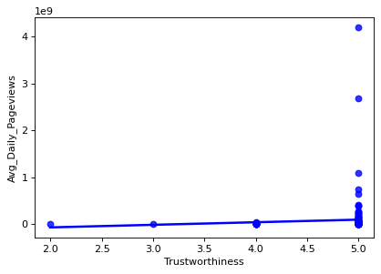

```
y = 15799720.52601 * x + 10218756.60535
```

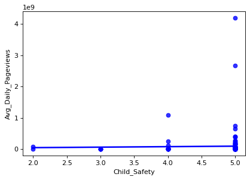

```python
yname = 'Avg_Daily_Pageviews'
xnames = ['Trustworthiness', 'Child_Safety']
plotScatterFirstOrder(df_multi, yname , xnames)
```

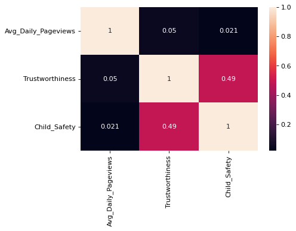

```python
corr1 = df_multi[['Avg_Daily_Pageviews', 'Trustworthiness', 'Child_Safety']].corr()
_ = sns.heatmap(corr1, annot=True)
```

```python
y_data = df_multi['Avg_Daily_Pageviews'].values

X_data_ar = np.array([df_multi['Trustworthiness'], df_multi['Child_Safety']])
X_data_T = X_data_ar.T
X_data = pd.DataFrame(X_data_T,columns = ['Trustworthiness', 'Child_Safety'])
X_data2 = sm.add_constant(X_data)
olsmod = sm.OLS(y_data, X_data2)
result = olsmod.fit()
print(result.summary())
```

```
                            OLS Regression Results
==============================================================================
Dep. Variable:                      y   R-squared:                       0.002
Model:                            OLS   Adj. R-squared:                 -0.009
Method:                 Least Squares   F-statistic:                    0.2085
Date:                Mon, 23 May 2022   Prob (F-statistic):              0.812
Time:                        12:31:18   Log-Likelihood:                -3627.1
No. Observations:                 171   AIC:                             7260.
Df Residuals:                     168   BIC:                             7270.
Df Model:                           2
Covariance Type:            nonrobust
===================================================================================
                      coef    std err          t      P>|t|      [0.025      0.975]
-----------------------------------------------------------------------------------
const           -1.789e+08    4.3e+08     -0.416      0.678   -1.03e+09     6.7e+08
Trustworthiness  5.746e+07   9.79e+07      0.587      0.558   -1.36e+08    2.51e+08
Child_Safety    -3.471e+06   6.72e+07     -0.052      0.959   -1.36e+08    1.29e+08
==============================================================================
Omnibus:                      295.650   Durbin-Watson:                   0.300
Prob(Omnibus):                  0.000   Jarque-Bera (JB):            43882.748
Skew:                           8.377   Prob(JB):                         0.00
Kurtosis:                      79.670   Cond. No.                         100.
==============================================================================

Warnings:
[1] Standard Errors assume that the covariance matrix of the errors is correctly specified.
```

We try to do variable transformation on Avg_Daily_Visitors.

```python
df_multi['log_Avg_Daily_Visitors'] = np.log(df_multi['Avg_Daily_Visitors'])
df_multi
```

|  | Trustworthiness | Avg_Daily_Visitors | Child_Safety | Avg_Daily_Pageviews | Facebook_likes | Twitter_mentions | Google_pluses | LinkedIn_mentions | Pinterest_pins | StumbleUpon_views | log_Avg_Daily_Visitors |
| --- | --- | --- | --- | --- | --- | --- | --- | --- | --- | --- | --- |
| 1 | 5 | 515007350 | 5 | 4192159833 | 94200 | 11200 | 11700000 | 1670 | 10800 | 246000 | 20.059692 |
| 2 | 5 | 506457282 | 5 | 2679159025 | 13500 | 16500 | 19300000 | 60000 | 47 | 329000 | 20.042951 |
| 3 | 5 | 270071255 | 4 | 1082985733 | 5870000 | 64400 | 127000 | 6230 | 4150 | 23100 | 19.414196 |
| 4 | 5 | 99572035 | 5 | 383352336 | 17200 | 1110 | 798000 | 7500 | 433 | 68900 | 18.416392 |
| 6 | 5 | 9282040 | 5 | 24690228 | 9 | 9370 | 7200 | 1120 | 16 | 136 | 16.043592 |
| ... | ... | ... | ... | ... | ... | ... | ... | ... | ... | ... | ... |
| 3337 | 5 | 1078499 | 5 | 5640550 | 2730 | 3970 | 7770 | 282 | 10 | 21 | 13.891081 |
| 3343 | 5 | 541924 | 5 | 2574142 | 2850 | 3700 | 2840 | 113 | 6 | 11 | 13.202881 |
| 3348 | 5 | 408955 | 5 | 1656271 | 883 | 2800 | 4230 | 389 | 112 | 62 | 12.921360 |
| 3354 | 5 | 285043 | 5 | 969149 | 2840 | 1960 | 8109 | 10 | 1 | 12 | 12.560395 |
| 3365 | 5 | 229928 | 5 | 646099 | 68 | 2060 | 7710 | 9 | 5 | 1 | 12.345521 |

171 rows × 11 columns

```python
y_data = df_multi['log_Avg_Daily_Visitors'].values

X_data_ar = np.array([df_multi['Trustworthiness'], df_multi['Child_Safety']])
X_data_T = X_data_ar.T
X_data = pd.DataFrame(X_data_T,columns = ['Trustworthiness', 'Child_Safety'])
X_data2 = sm.add_constant(X_data)
olsmod = sm.OLS(y_data, X_data2)
result = olsmod.fit()
print(result.summary())
```

```
                            OLS Regression Results
==============================================================================
Dep. Variable:                      y   R-squared:                       0.021
Model:                            OLS   Adj. R-squared:                  0.009
Method:                 Least Squares   F-statistic:                     1.800
Date:                Mon, 23 May 2022   Prob (F-statistic):              0.169
Time:                        12:31:18   Log-Likelihood:                -349.71
No. Observations:                 171   AIC:                             705.4
Df Residuals:                     168   BIC:                             714.9
Df Model:                           2
Covariance Type:            nonrobust
===================================================================================
                      coef    std err          t      P>|t|      [0.025      0.975]
-----------------------------------------------------------------------------------
const              11.0675      2.040      5.424      0.000       7.040      15.095
Trustworthiness     0.8597      0.465      1.851      0.066      -0.057       1.777
Child_Safety       -0.1721      0.319     -0.540      0.590      -0.801       0.457
==============================================================================
Omnibus:                        8.209   Durbin-Watson:                   1.045
Prob(Omnibus):                  0.016   Jarque-Bera (JB):                8.641
Skew:                           0.546   Prob(JB):                       0.0133
Kurtosis:                       2.852   Cond. No.                         100.
==============================================================================

Warnings:
[1] Standard Errors assume that the covariance matrix of the errors is correctly specified.
```

The R-squared = 0.021 but Adj.R-squared = 0.009, it seems to have overfitting problem.

Moreover, the R-squared is too small, so we decide to add more variables.

## Adding all variables

independent variables: 'Trustworthiness', 'Child_Safety', 'Facebook_likes', 'Twitter_mentions', 'Google_pluses', 'LinkedIn_mentions', 'Pinterest_pins', 'StumbleUpon_views'

dependent variables: Avg_Daily_Pageviews

## Avg_Daily_Pageviews

### Plot the scatter diagram

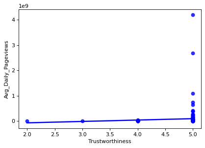

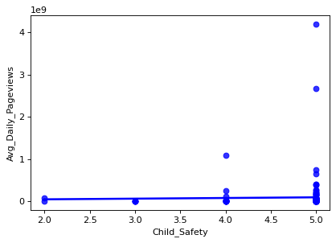

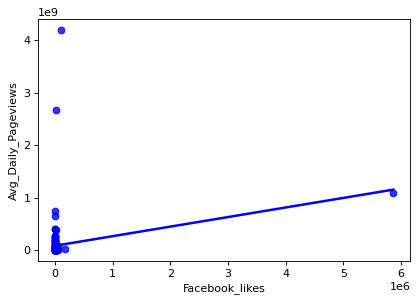

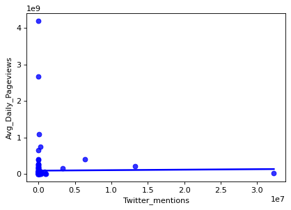

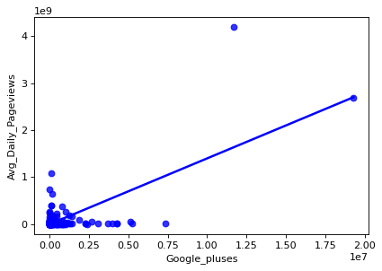

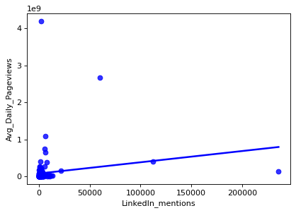

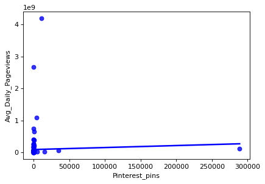

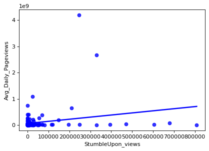

```python
# linear
y_var = df_multi['Avg_Daily_Pageviews'].values
xnames = ['Trustworthiness', 'Child_Safety', 'Facebook_likes', 'Twitter_mentions', 'Google_pluses', 'LinkedIn_mentions', 'Pinterest_pins', 'StumbleUpon_views']

for aname in xnames:
    x_var = df_multi[aname].values
    _ = sns.regplot(x = x_var, y = y_var, data = df_multi, color = 'b', ci = None)
    plt.xlabel(aname)
    plt.ylabel('Avg_Daily_Pageviews')
    plt.show()
```

```
y = -164945235.81023 * x + 27429857.40476 * x^2 + 231420620.65210
```

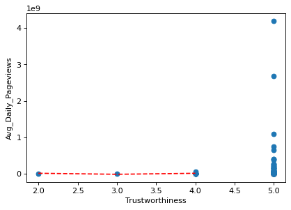

```
y = 152433200.46729 * x + -17370720.50698 * x^2 + -239787245.28825
```

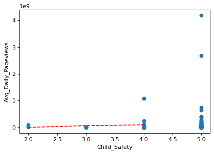

```
y = 9503.27480 * x + -0.00159 * x^2 + 46298167.64838
```

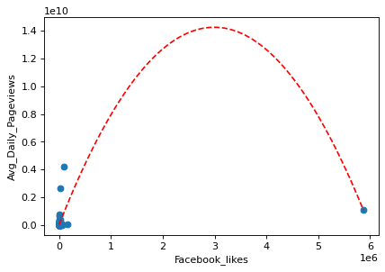

```
y = 29.29046 * x + -0.00000 * x^2 + 83366392.69784
```

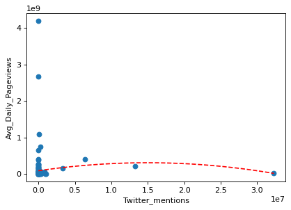

```
y = 45.03215 * x + 0.00001 * x^2 + 28075432.94548
```

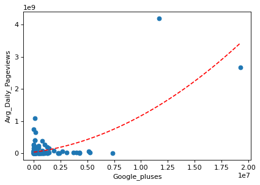

```
y = 23826.23185 * x + -0.10162 * x^2 + 36845070.21493
```

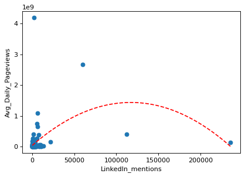

```
y = 34771.23678 * x + -0.12003 * x^2 + 71988546.83237
```

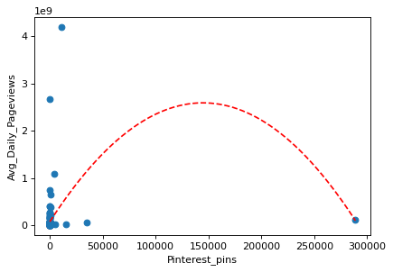

```
y = 4281.54871 * x + -0.00591 * x^2 + 16557225.87295
```

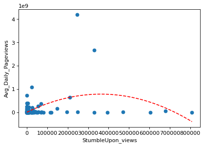

```python
yname = 'Avg_Daily_Pageviews'
xnames = ['Trustworthiness', 'Child_Safety', 'Facebook_likes', 'Twitter_mentions', 'Google_pluses', 'LinkedIn_mentions', 'Pinterest_pins', 'StumbleUpon_views']
plotScatterSecondOrder(df_multi,yname,xnames)
```

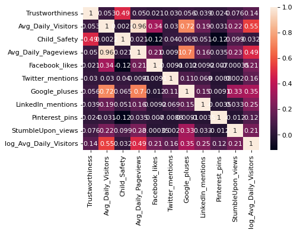

```python
corr1 = df_multi.corr()
_ = sns.heatmap(corr1, annot=True)
```

### Propose a statistical model

Second Order Model doesn't fit the Avg_Daily_Pageviews data very well.

So we use First Order Model.

### Fit the model

```python
y_data = df_multi['Avg_Daily_Pageviews'].values

X_data_ar = np.array([df_multi['Trustworthiness'], df_multi['Child_Safety'],df_multi['Facebook_likes'], df_multi['Twitter_mentions'], df_multi['Google_pluses'], df_multi['LinkedIn_mentions'], df_multi['Pinterest_pins'], df_multi['StumbleUpon_views']])
X_data_T = X_data_ar.T
X_data = pd.DataFrame(X_data_T,columns = ['Trustworthiness', 'Child_Safety', 'Facebook_likes', 'Twitter_mentions', 'Google_pluses', 'LinkedIn_mentions', 'Pinterest_pins', 'StumbleUpon_views'])
X_data2 = sm.add_constant(X_data)
olsmod = sm.OLS(y_data, X_data2)
result = olsmod.fit()
print(result.summary())
```

```
                            OLS Regression Results
==============================================================================
Dep. Variable:                      y   R-squared:                       0.549
Model:                            OLS   Adj. R-squared:                  0.527
Method:                 Least Squares   F-statistic:                     24.68
Date:                Mon, 23 May 2022   Prob (F-statistic):           1.49e-24
Time:                        12:31:31   Log-Likelihood:                -3559.2
No. Observations:                 171   AIC:                             7136.
Df Residuals:                     162   BIC:                             7165.
Df Model:                           8
Covariance Type:            nonrobust
=====================================================================================
                        coef    std err          t      P>|t|      [0.025      0.975]
-------------------------------------------------------------------------------------
const             -4.405e+07   2.95e+08     -0.149      0.882   -6.27e+08    5.39e+08
Trustworthiness    4.435e+06   6.77e+07      0.066      0.948   -1.29e+08    1.38e+08
Child_Safety       2.241e+06   4.72e+07      0.047      0.962   -9.09e+07    9.54e+07
Facebook_likes      188.7514     47.074      4.010      0.000      95.793     281.710
Twitter_mentions    -10.1732      7.756     -1.312      0.191     -25.488       5.142
Google_pluses       140.9910     11.333     12.441      0.000     118.611     163.371
LinkedIn_mentions  1025.6011   1037.166      0.989      0.324   -1022.507    3073.709
Pinterest_pins      477.8844    948.176      0.504      0.615   -1394.495    2350.263
StumbleUpon_views   -29.3311    197.116     -0.149      0.882    -418.580     359.918
==============================================================================
Omnibus:                      212.730   Durbin-Watson:                   1.418
Prob(Omnibus):                  0.000   Jarque-Bera (JB):            17697.473
Skew:                           4.630   Prob(JB):                         0.00
Kurtosis:                      51.971   Cond. No.                     3.99e+07
==============================================================================

Warnings:
[1] Standard Errors assume that the covariance matrix of the errors is correctly specified.
[2] The condition number is large, 3.99e+07. This might indicate that there are
strong multicollinearity or other numerical problems.
```

### Regression Diagnostics (multicollinearity and autocorrelation)

#### multicollinearity

We found that the Coef of StumbleUpon_views = -29.3311 < 0, which isn't accordance to our scatter plot.

There multicollinearity is exist.

```python
import time
import itertools

def processSubset(y_v, X_v, feature_set):
    X_v_a = sm.add_constant(X_v[list(feature_set)])
    model = sm.OLS(y_v,X_v_a)
    regr = model.fit()
    RSS = regr.rsquared_adj
    return {"model":regr, "RSS":RSS}

def getBest(y_g, X_g, k):
    tic = time.time()
    results = []
    for combo in itertools.combinations(X_g.columns, k):
        results.append(processSubset(y_g, X_g, combo))
    models = pd.DataFrame(results)
    best_model = models.loc[models['RSS'].argmax()]
    toc = time.time()
    return best_model
```

```python
y_var = df_multi['Avg_Daily_Pageviews'].values
X_data_ar = np.array([df_multi['Trustworthiness'], df_multi['Child_Safety'],df_multi['Facebook_likes'], df_multi['Twitter_mentions'], df_multi['Google_pluses'], df_multi['LinkedIn_mentions'], df_multi['Pinterest_pins'], df_multi['StumbleUpon_views']])
X_data_T = X_data_ar.T

X_var = pd.DataFrame(X_data_T, columns=['Trustworthiness', 'Child_Safety', 'Facebook_likes', 'Twitter_mentions', 'Google_pluses', 'LinkedIn_mentions', 'Pinterest_pins', 'StumbleUpon_views'])
models_best = pd.DataFrame(columns=["RSS", "model"])
tic = time.time()
for i in range(1,8):
    models_best.loc[i] = getBest(y_var, X_var, i)
toc = time.time()
print("Total elapsed time:", (toc-tic), "seconds.")
Fb = models_best[models_best['RSS']==models_best.RSS.max()].index.values
print(models_best.loc[Fb[0], "model"].summary())
columns = ['Facebook_likes', 'Twitter_mentions', 'Google_pluses', 'LinkedIn_mentions']
result = models_best.loc[Fb[0], "model"]
print()
s = f"Estimated model: y = {result.params[0]:.4f} "
for i in range(1, len(result.params)):
    s += f'+ {result.params[i]:.4f} {columns[i - 1]} '
print(s)
```

```
Total elapsed time: 1.4967050552368164 seconds.
                            OLS Regression Results
==============================================================================
Dep. Variable:                      y   R-squared:                       0.549
Model:                            OLS   Adj. R-squared:                  0.538
Method:                 Least Squares   F-statistic:                     50.42
Date:                Mon, 23 May 2022   Prob (F-statistic):           1.00e-27
Time:                        12:31:33   Log-Likelihood:                -3559.4
No. Observations:                 171   AIC:                             7129.
Df Residuals:                     166   BIC:                             7144.
Df Model:                           4
Covariance Type:            nonrobust
=====================================================================================
                        coef    std err          t      P>|t|      [0.025      0.975]
-------------------------------------------------------------------------------------
const             -1.121e+07    2.2e+07     -0.510      0.611   -5.46e+07    3.22e+07
Facebook_likes      188.6553     45.997      4.101      0.000      97.840     279.470
Twitter_mentions    -10.1434      7.659     -1.324      0.187     -25.265       4.978
Google_pluses       140.5567     10.560     13.310      0.000     119.707     161.407
LinkedIn_mentions  1030.4514   1024.366      1.006      0.316    -992.014    3052.917
==============================================================================
Omnibus:                      212.949   Durbin-Watson:                   1.410
Prob(Omnibus):                  0.000   Jarque-Bera (JB):            17750.347
Skew:                           4.638   Prob(JB):                         0.00
Kurtosis:                      52.043   Cond. No.                     2.96e+06
==============================================================================

Warnings:
[1] Standard Errors assume that the covariance matrix of the errors is correctly specified.
[2] The condition number is large, 2.96e+06. This might indicate that there are
strong multicollinearity or other numerical problems.

Estimated model: y = -11211232.0340 + 188.6553 Facebook_likes + -10.1434 Twitter_mentions + 140.5567 Google_pluses + 1030.4514 LinkedIn_mentions
```

### Autocorrelation

#### Durbin_Watson_test

$H_0:$ The data are not first-order correlated

$H_1:$ The data are first-order correlated

```python
st, data, ss = sso.summary_table(result, alpha=0.05)
y_pre = data[:, 2]

SD = data[:, 10]
mu = np.mean(SD)
sigma = np.std(SD)
print(SD)
print('SD_mu = ', mu)
print('SD_sigma = ', sigma)
```

[output not shown]

```python
d = Durbin_Watson_test(SD)
print(d)
```

[output not shown]

```python
dL = 1.571
dU = 1.679
print("dL =",dL)
print("dU =",dU)
print("4-dU = %.4f"%(4-dU))
print("4-dL = %.4f"%(4-dL))
```

```
dL = 1.571
dU = 1.679
4-dU = 2.3210
4-dL = 2.4290
```

```python
if d < dL or d > 4-dL:
    print("first order auto-correlation exists")
elif dL < d <= dU or 4-dU < d <= 4-dL:
    print("the test is inconclusive")
elif dU < d <= 4-dU:
    print("there is no evidence for first order auto-correlation")
```

```
first order auto-correlation exists
```

We can find 𝑑𝐿 = 1.571 𝑑𝑈 = 1.679 , when k = 4 , n = 171.

### Residual analysis

```python
Normality(SD)
```

```
Normality test for errors using Shapiro Test
 - H0: Errors are normally distributed.
 - H1: Errors are not normally distributed.

pvalue of Shapiro Test = 9.193160321859865e-22

Since p-value < 0.05, we reject H0 and conclude errors are not normally distributed.
```

```
Homoscedasticity Test
 - H0: Homoscedasticity
 - H1: Heteroscedasticity
```

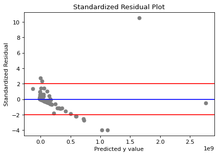

```python
Homoscedasticity(data, "Predicted y value")
```

```python
Randomness(SD)
```

```
Randomness Test using Runs Test
 - H0: Randomness exists.
 - H1: Randomness does not exist

runs =  79
n1 =  87
n2 =  85

runs_exp =  86.98837209302326
stan_dev =  6.5373473898371435
z =  -1.2219592468715759
pval_z =  0.22172303864334242

Since p-value > 0.05, we do not reject H0 and we may conclude randomness exists.
```

### outliers

```python
Outlier(SD)
```

```
Outliers by SD =

0      10.524036
2      -3.954618
21     -2.526318
32      2.340607
36     -2.703905
79      2.788115
95     -2.208506
105    -3.937271
157    -2.201576
Name: SD, dtype: float64

Sample [1, 3, 22, 33, 37, 80, 96, 106, 158] are outliers.
```

### influential observations

```python
X_data_ar = np.array([df_multi['Facebook_likes'], df_multi['Twitter_mentions'], df_multi['Google_pluses'], df_multi['LinkedIn_mentions']])
X_data_T = X_data_ar.T
X_data = pd.DataFrame(X_data_T, columns = ['Facebook_likes', 'Twitter_mentions', 'Google_pluses', 'LinkedIn_mentions'])
X_data2 = sm.add_constant(X_data)
X = X_data2
H_b = np.dot(X, np.linalg.solve(np.dot(X.T, X), X.T))
df_multi['hii'] = np.diagonal(H_b)
k = result.df_model
n = len(df_multi['hii'])
h_level = 3 * (k+1) / n
print("h_level = ", h_level)
print(" \n")
filter = (df_multi['hii'] > h_level )
print("Influential Observations by hi = \n")
print(df_multi['hii'].loc[filter])
```

```
h_level =  0.08771929824561403


Influential Observations by hi =

1      0.196359
2      0.543798
3      0.998803
22     0.790549
23     0.143942
34     0.200914
267    0.826352
Name: hii, dtype: float64
```

### cook

```python
s2_e = result.mse_resid
k = result.df_model
y_a = data[:, 1]
y_f = data[:, 2]
h_i = df_multi['hii']
CD_arr = np.square(y_a - y_f) / s2_e / (k - 1) * h_i / np.square(1 - h_i)
CD = np.array(CD_arr)
df1_cd = pd.DataFrame(CD,columns = ['CD'])
display(df1_cd.head())
filter = (df1_cd['CD'] > 1 )
print("Influential Observations by Cook's Distances = \n")
print(df1_cd['CD'].loc[filter])
```

|  | CD |
| --- | --- |
| 0 | 9.020524 |
| 1 | 0.090113 |
| 2 | 4350.271738 |
| 3 | 0.002125 |
| 4 | 0.000035 |

```
Influential Observations by Cook's Distances =

0        9.020524
2     4350.271738
10       1.649800
37       5.220654
Name: CD, dtype: float64
```

### Assess the fitted model

#### f-test

```python
f_res = result.fvalue
MSE = result.mse_resid
df_model = result.df_model
df_error = result.df_resid
MSR = f_res * MSE
SSR = MSR * df_model
print("SSR = ", SSR, "df = ", df_model, "MSR = ", MSR)
print("SSE = ", MSE * df_error, "df = ", df_error, "MSE = ", MSE)
print("F = ", MSR / MSE)
A = np.identity(len(result.params))
A = A[1:,:]
print(result.f_test(A))
```

```
SSR =  1.4613572885337221e+19 df =  4.0 MSR =  3.6533932213343053e+18
SSE =  1.2027362470408894e+19 df =  166.0 MSE =  7.245399078559574e+16
F =  50.423629971540784
<F test: F=array([[50.42362997]]), p=1.0029007748462536e-27, df_denom=166, df_num=4>
```

#### std err estimate

```python
print("standard error = ", result.mse_resid ** 0.5)

print("mean of y", df_multi['Avg_Daily_Pageviews'].mean())
print("std of y", df_multi['Avg_Daily_Pageviews'].std())
```

```
standard error =  269172789.83135676
mean of y 86537874.46783626
std of y 395867887.6160144
```

The standard err of estimate = 269172789.83135676, mean of y = 86537874.46783626. It appears that the standard error of estimate is quite large.

#### r^2

```python
SSR = result.ssr
R2 = result.rsquared
print("SSR = ", SSR)
print("R2 = ", R2)
```

```
SSR =  1.2027362470408894e+19
R2 =  0.5485382810399432
```

54.8% of the variation in Avg_Daily_Pageviews is explained by independent variables. The rest remains unexplained by this model.

#### testing of the coefficients

$H_0$: $\beta_i$ = 0

$H_1$: $\beta_i \neq$ 0

pvalue of Facebook_likes = 0.000 < 0.05, we can reject H0. There is sufficient evidence to conclude that there is a linear relationship between the amount of Facebook_likes and the Avg_Daily_Pageviews.

pvalue of Twitter_mentions = 0.187 > 0.05, we can't reject H0. There is insufficient evidence to conclude that there is a linear relationship between the amount of Twitter_mentions and the Avg_Daily_Pageviews.

pvalue of Google_pluses = 0.000 < 0.05, we can reject H0. There is sufficient evidence to conclude that there is a linear relationship between the amount of Google_pluses and the Avg_Daily_Pageviews.

pvalue of LinkedIn_mentions = 0.316 > 0.05, we can't reject H0. There is insufficient evidence to conclude that there is a linear relationship between the amount of LinkedIn_mentions and the Avg_Daily_Pageviews.

### interpretation

Interpret:

b0 = -11211232.0340, when all the independent variables are zero , Y = -11211232.0340. However, in this case, the intercept is probably meaningless because we don't have all variables equal to 0.

X1: when Facebook_likes increases by 1 unit, Y will increase by 188.6553 units

Since p-value = 1.0029007748462231e-27 < alpha = 0.05, we can reject H0. There is enough evidence to conclude that the model is valid with r-squared = 0.549 and Adj. R-squared = 0.538.

## Avg_Daily_Visitors

```python
df_multi
```

|  | Trustworthiness | Avg_Daily_Visitors | Child_Safety | Avg_Daily_Pageviews | Facebook_likes | Twitter_mentions | Google_pluses | LinkedIn_mentions | Pinterest_pins | StumbleUpon_views | log_Avg_Daily_Visitors | hii |
| --- | --- | --- | --- | --- | --- | --- | --- | --- | --- | --- | --- | --- |
| 1 | 5 | 515007350 | 5 | 4192159833 | 94200 | 11200 | 11700000 | 1670 | 10800 | 246000 | 20.059692 | 0.196359 |
| 2 | 5 | 506457282 | 5 | 2679159025 | 13500 | 16500 | 19300000 | 60000 | 47 | 329000 | 20.042951 | 0.543798 |
| 3 | 5 | 270071255 | 4 | 1082985733 | 5870000 | 64400 | 127000 | 6230 | 4150 | 23100 | 19.414196 | 0.998803 |
| 4 | 5 | 99572035 | 5 | 383352336 | 17200 | 1110 | 798000 | 7500 | 433 | 68900 | 18.416392 | 0.006191 |
| 6 | 5 | 9282040 | 5 | 24690228 | 9 | 9370 | 7200 | 1120 | 16 | 136 | 16.043592 | 0.006587 |
| ... | ... | ... | ... | ... | ... | ... | ... | ... | ... | ... | ... | ... |
| 3337 | 5 | 1078499 | 5 | 5640550 | 2730 | 3970 | 7770 | 282 | 10 | 21 | 13.891081 | 0.006633 |
| 3343 | 5 | 541924 | 5 | 2574142 | 2850 | 3700 | 2840 | 113 | 6 | 11 | 13.202881 | 0.006655 |
| 3348 | 5 | 408955 | 5 | 1656271 | 883 | 2800 | 4230 | 389 | 112 | 62 | 12.921360 | 0.006636 |
| 3354 | 5 | 285043 | 5 | 969149 | 2840 | 1960 | 8109 | 10 | 1 | 12 | 12.560395 | 0.006654 |
| 3365 | 5 | 229928 | 5 | 646099 | 68 | 2060 | 7710 | 9 | 5 | 1 | 12.345521 | 0.006661 |

171 rows × 12 columns

### Plot the scatter diagram

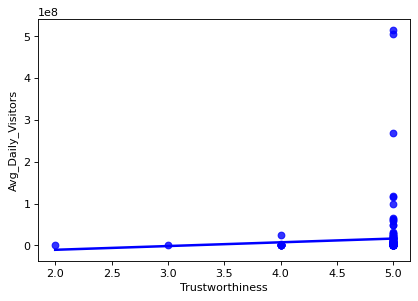

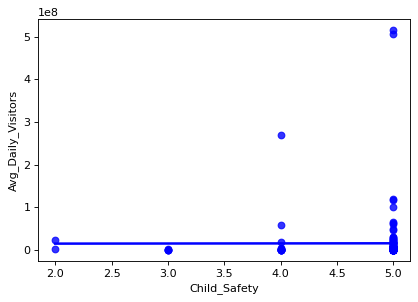

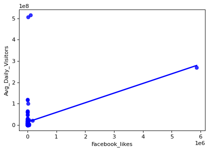

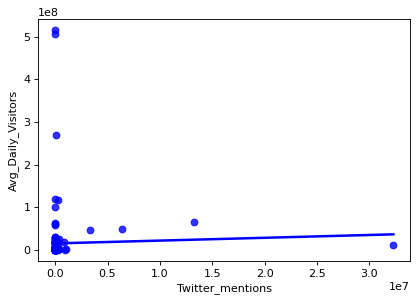

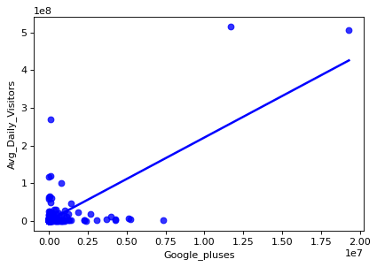

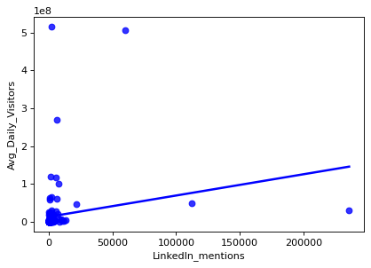

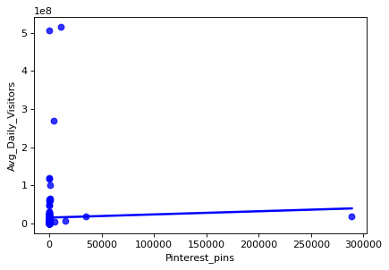

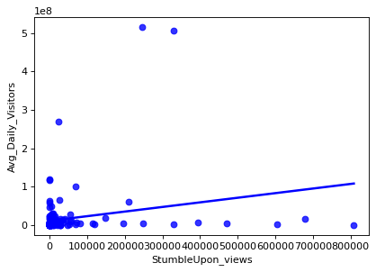

```python
# linear
y_var = df_multi['Avg_Daily_Visitors'].values
xnames = ['Trustworthiness', 'Child_Safety', 'Facebook_likes', 'Twitter_mentions', 'Google_pluses', 'LinkedIn_mentions', 'Pinterest_pins', 'StumbleUpon_views']

for aname in xnames:
    x_var = df_multi[aname].values
    _ = sns.regplot(x = x_var, y = y_var, data = df_multi, color = 'b', ci = None)
    plt.xlabel(aname)
    plt.ylabel('Avg_Daily_Visitors')
    plt.show()
```

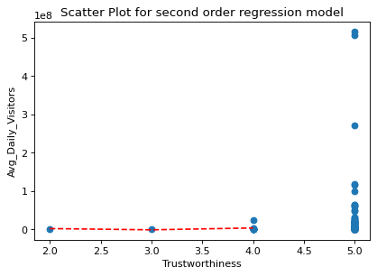

```
y = -23467574.04824 * x + 4045211.31437 * x^2 + 32639722.92550
```

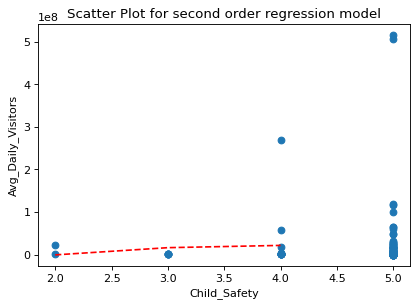

```
y = 46086535.41761 * x + -5826192.74810 * x^2 + -69618699.32283
```

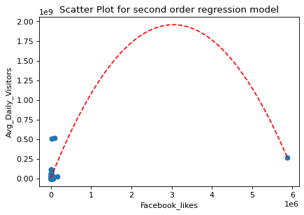

```
y = 1281.31514 * x + -0.00021 * x^2 + 9352675.07714
```

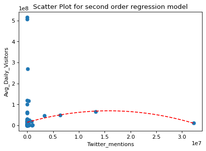

```
y = 6.93687 * x + -0.00000 * x^2 + 14646030.59600
```

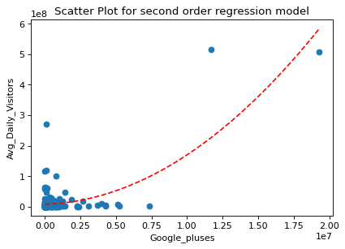

```
y = 1.51500 * x + 0.00000 * x^2 + 8147848.16031
```

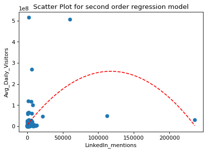

```
y = 4312.98709 * x + -0.01834 * x^2 + 6467387.19555
```

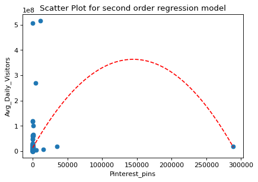

```
y = 4830.71100 * x + -0.01669 * x^2 + 13471036.87323
```

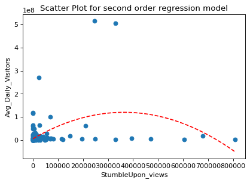

```
y = 629.61630 * x + -0.00087 * x^2 + 5152124.75578
```

```python
## second order
def objective(x, a, b, c):
    return a * x + b * x**2 + c
y_var = df_multi['Avg_Daily_Visitors'].values
xnames = ['Trustworthiness', 'Child_Safety', 'Facebook_likes', 'Twitter_mentions', 'Google_pluses', 'LinkedIn_mentions', 'Pinterest_pins', 'StumbleUpon_views']
for aname in xnames:
    x_var = df_multi[aname].values
    popt, _ = curve_fit(objective, x_var, y_var)
    a, b, c = popt
    plt.scatter(x_var, y_var)
    x_line = np.arange(min(x_var), max(x_var), 1)
    y_line = objective(x_line, a, b, c)
    plt.title('Scatter Plot for second order regression model')
    plt.plot(x_line, y_line, '--', color='red')
    plt.xlabel(aname)
    plt.ylabel('Avg_Daily_Visitors')
    plt.show()
    print('y = %.5f * x + %.5f * x^2 + %.5f' % (a, b, c))
```

### Propose a statistical model and fit the model

#### Use first-order

```python
y_data = df_multi['Avg_Daily_Visitors'].values

X_data_ar = np.array([df_multi['Trustworthiness'], df_multi['Child_Safety'],df_multi['Facebook_likes'], df_multi['Twitter_mentions'], df_multi['Google_pluses'], df_multi['LinkedIn_mentions'], df_multi['Pinterest_pins'], df_multi['StumbleUpon_views']])
X_data_T = X_data_ar.T
columns = ['Trustworthiness', 'Child_Safety', 'Facebook_likes', 'Twitter_mentions', 'Google_pluses', 'LinkedIn_mentions', 'Pinterest_pins', 'StumbleUpon_views']
X_data = pd.DataFrame(X_data_T,columns=['Trustworthiness', 'Child_Safety', 'Facebook_likes', 'Twitter_mentions', 'Google_pluses', 'LinkedIn_mentions', 'Pinterest_pins', 'StumbleUpon_views'])
X_data2 = sm.add_constant(X_data)
olsmod = sm.OLS(y_data, X_data2)
result = olsmod.fit()
print(result.summary())
print()
s = f"Estimated model: y = {result.params[0]:.4f} "
for i in range(1, len(result.params)):
    s += f'+ {result.params[i]:.4f} {columns[i - 1]} '
print(s)
```

```
                            OLS Regression Results
==============================================================================
Dep. Variable:                      y   R-squared:                       0.651
Model:                            OLS   Adj. R-squared:                  0.633
Method:                 Least Squares   F-statistic:                     37.69
Date:                Mon, 23 May 2022   Prob (F-statistic):           2.78e-33
Time:                        12:31:51   Log-Likelihood:                -3216.1
No. Observations:                 171   AIC:                             6450.
Df Residuals:                     162   BIC:                             6479.
Df Model:                           8
Covariance Type:            nonrobust
=====================================================================================
                        coef    std err          t      P>|t|      [0.025      0.975]
-------------------------------------------------------------------------------------
const             -3.785e+06   3.97e+07     -0.095      0.924   -8.22e+07    7.46e+07
Trustworthiness    1.119e+06    9.1e+06      0.123      0.902   -1.68e+07    1.91e+07
Child_Safety      -5.011e+05   6.35e+06     -0.079      0.937    -1.3e+07     1.2e+07
Facebook_likes       46.0489      6.331      7.274      0.000      33.547      58.550
Twitter_mentions     -1.1581      1.043     -1.110      0.268      -3.218       0.902
Google_pluses        22.1081      1.524     14.505      0.000      19.098      25.118
LinkedIn_mentions   240.1944    139.483      1.722      0.087     -35.245     515.633
Pinterest_pins       55.8839    127.515      0.438      0.662    -195.922     307.690
StumbleUpon_views   -10.8224     26.509     -0.408      0.684     -63.170      41.526
==============================================================================
Omnibus:                      100.930   Durbin-Watson:                   1.393
Prob(Omnibus):                  0.000   Jarque-Bera (JB):             2422.564
Skew:                           1.599   Prob(JB):                         0.00
Kurtosis:                      21.160   Cond. No.                     3.99e+07
==============================================================================

Warnings:
[1] Standard Errors assume that the covariance matrix of the errors is correctly specified.
[2] The condition number is large, 3.99e+07. This might indicate that there are
strong multicollinearity or other numerical problems.

Estimated model: y = -3785328.9770 + 1119397.1338 Trustworthiness + -501114.0961 Child_Safety + 46.0489 Facebook_likes + -1.1581 Twitter_mentions + 22.1081 Google_pluses + 240.1944 LinkedIn_mentions + 55.8839 Pinterest_pins + -10.8224 StumbleUpon_views
```

### Regression Diagnostics (multicollinearity and autocorrelation)

#### Multicollinearity

since the StumbleUpon_views and Twitter_mention conflict with slope diagram and correlation, we try to use best selection to solve it.

#### bestset

```python
import time
import itertools

def processSubset(y_v, X_v, feature_set):
    X_v_a = sm.add_constant(X_v[list(feature_set)])
    model = sm.OLS(y_v,X_v_a)
    regr = model.fit()
    RSS = regr.rsquared_adj
    return {"model":regr, "RSS":RSS}

def getBest(y_g, X_g, k):
    tic = time.time()
    results = []
    for combo in itertools.combinations(X_g.columns, k):
        results.append(processSubset(y_g, X_g, combo))
    models = pd.DataFrame(results)
    best_model = models.loc[models['RSS'].argmax()]
    toc = time.time()
    return best_model
```

```python
y_var = df_multi['Avg_Daily_Visitors'].values
X_data_ar = np.array([df_multi['Trustworthiness'], df_multi['Child_Safety'],df_multi['Facebook_likes'], df_multi['Twitter_mentions'], df_multi['Google_pluses'], df_multi['LinkedIn_mentions'], df_multi['Pinterest_pins'], df_multi['StumbleUpon_views']])
X_data_T = X_data_ar.T
X_var = pd.DataFrame(X_data_T,columns = ['Trustworthiness', 'Child_Safety', 'Facebook_likes', 'Twitter_mentions', 'Google_pluses', 'LinkedIn_mentions', 'Pinterest_pins', 'StumbleUpon_views'])

models_best = pd.DataFrame(columns=["RSS", "model"])
tic = time.time()
for i in range(0,8):
    models_best.loc[i] = getBest(y_var, X_var, i)
toc = time.time()
print("Total elapsed time:", (toc-tic), "seconds.")
result = models_best[models_best['RSS']==models_best.RSS.max()].index.values
print(models_best.loc[result[0], "model"].summary())
```

```
Total elapsed time: 0.6678135395050049 seconds.
                            OLS Regression Results
==============================================================================
Dep. Variable:                      y   R-squared:                       0.650
Model:                            OLS   Adj. R-squared:                  0.641
Method:                 Least Squares   F-statistic:                     76.96
Date:                Mon, 23 May 2022   Prob (F-statistic):           8.54e-37
Time:                        12:31:52   Log-Likelihood:                -3216.3
No. Observations:                 171   AIC:                             6443.
Df Residuals:                     166   BIC:                             6458.
Df Model:                           4
Covariance Type:            nonrobust
=====================================================================================
                        coef    std err          t      P>|t|      [0.025      0.975]
-------------------------------------------------------------------------------------
const             -8.559e+05   2.96e+06     -0.289      0.773    -6.7e+06    4.99e+06
Facebook_likes       46.1482      6.188      7.458      0.000      33.931      58.365
Twitter_mentions     -1.1468      1.030     -1.113      0.267      -3.181       0.887
Google_pluses        21.9098      1.421     15.422      0.000      19.105      24.715
LinkedIn_mentions   240.9073    137.807      1.748      0.082     -31.174     512.988
==============================================================================
Omnibus:                      101.097   Durbin-Watson:                   1.385
Prob(Omnibus):                  0.000   Jarque-Bera (JB):             2404.047
Skew:                           1.607   Prob(JB):                         0.00
Kurtosis:                      21.085   Cond. No.                     2.96e+06
==============================================================================

Warnings:
[1] Standard Errors assume that the covariance matrix of the errors is correctly specified.
[2] The condition number is large, 2.96e+06. This might indicate that there are
strong multicollinearity or other numerical problems.
```

#### Stepwise_forward

```python
def forward_selection(input_df, depv="y", indepv = ["x1"]):
    selected = []
    candidates = indepv.copy()
    best_adjr2 = -1
    best_subset = []
    while len(candidates) > 0:
        print("Current Candidates: ", candidates)
        tmp_indep_subset = []
        tmp_model_adjr = []
        tmp_model_nindep = []
        for acandidate in candidates:
            tmplist = selected.copy()
            tmplist.append(acandidate)
            modelstr = depv + " ~ " + "+".join(tmplist)
            result6tmp = smf.ols(modelstr, data=input_df).fit()
            tmp_indep_subset.append(tmplist)
            tmp_model_adjr.append(result6tmp.rsquared_adj)
            tmp_model_nindep.append(len(tmplist))
        tmp_adjr2 = np.array(tmp_model_adjr)
        tmpind = tmp_adjr2.argmax()
        this_adjr2 = tmp_adjr2[tmpind]
        selected = tmp_indep_subset[tmpind]
        if this_adjr2 <= 0:
            raise("Encounterd negative Adj R2. Stop.")
        print("===============")
        print("Current best model: ", selected)
        print("Current best AdjR2: ", this_adjr2)
        if this_adjr2 > best_adjr2:
            #print(" best result updated")
            best_adjr2 = this_adjr2
            best_subset = selected
        candidates = set(candidates) - set(selected)
        candidates = list(candidates)
    print("best_adjr2 = ", best_adjr2)
    print("best_subset = ", best_subset)
    modelstr = depv + " ~ " + "+".join(best_subset)
    result6b = smf.ols(modelstr, data=input_df).fit()
    print(result6b.summary())
```

```python
df_multi2 = df_multi.copy()
df_multi2.rename(columns = {'Trustworthiness' : 'C_Trustworthiness', 'Child_Safety' : 'C_Child_Safety','Facebook_likes' : 'C_Facebook_likes', 'Twitter_mentions' : 'C_Twitter_mentions','Google_pluses' : 'C_Google_pluses', 'LinkedIn_mentions' : 'C_LinkedIn_mentions','Pinterest_pins':'C_Pinterest_pins','StumbleUpon_views':'C_StumbleUpon_views'}, inplace = True)
forward_selection(input_df = df_multi2, depv = 'Avg_Daily_Visitors', indepv = ['C_Trustworthiness', 'C_Child_Safety', 'C_Facebook_likes', 'C_Twitter_mentions', 'C_Google_pluses', 'C_LinkedIn_mentions', 'C_Pinterest_pins', 'C_StumbleUpon_views'])
```

```
Current Candidates:  ['C_Trustworthiness', 'C_Child_Safety', 'C_Facebook_likes', 'C_Twitter_mentions', 'C_Google_pluses', 'C_LinkedIn_mentions', 'C_Pinterest_pins', 'C_StumbleUpon_views']
===============
Current best model:  ['C_Google_pluses']
Current best AdjR2:  0.5199017450461869
Current Candidates:  ['C_Pinterest_pins', 'C_Twitter_mentions', 'C_Trustworthiness', 'C_Facebook_likes', 'C_Child_Safety', 'C_StumbleUpon_views', 'C_LinkedIn_mentions']
===============
Current best model:  ['C_Google_pluses', 'C_Facebook_likes']
Current best AdjR2:  0.6367421417842225
Current Candidates:  ['C_Pinterest_pins', 'C_Twitter_mentions', 'C_Trustworthiness', 'C_Child_Safety', 'C_StumbleUpon_views', 'C_LinkedIn_mentions']
===============
Current best model:  ['C_Google_pluses', 'C_Facebook_likes', 'C_LinkedIn_mentions']
Current best AdjR2:  0.6407132518123069
Current Candidates:  ['C_Pinterest_pins', 'C_Twitter_mentions', 'C_Trustworthiness', 'C_Child_Safety', 'C_StumbleUpon_views']
===============
Current best model:  ['C_Google_pluses', 'C_Facebook_likes', 'C_LinkedIn_mentions', 'C_Twitter_mentions']
Current best AdjR2:  0.6412265878251246
Current Candidates:  ['C_Child_Safety', 'C_Trustworthiness', 'C_StumbleUpon_views', 'C_Pinterest_pins']
===============
Current best model:  ['C_Google_pluses', 'C_Facebook_likes', 'C_LinkedIn_mentions', 'C_Twitter_mentions', 'C_Pinterest_pins']
Current best AdjR2:  0.6395312112150722
Current Candidates:  ['C_Child_Safety', 'C_StumbleUpon_views', 'C_Trustworthiness']
===============
Current best model:  ['C_Google_pluses', 'C_Facebook_likes', 'C_LinkedIn_mentions', 'C_Twitter_mentions', 'C_Pinterest_pins', 'C_StumbleUpon_views']
Current best AdjR2:  0.6377066676233996
Current Candidates:  ['C_Child_Safety', 'C_Trustworthiness']
===============
Current best model:  ['C_Google_pluses', 'C_Facebook_likes', 'C_LinkedIn_mentions', 'C_Twitter_mentions', 'C_Pinterest_pins', 'C_StumbleUpon_views', 'C_Trustworthiness']
Current best AdjR2:  0.6355049888640281
Current Candidates:  ['C_Child_Safety']
===============
Current best model:  ['C_Google_pluses', 'C_Facebook_likes', 'C_LinkedIn_mentions', 'C_Twitter_mentions', 'C_Pinterest_pins', 'C_StumbleUpon_views', 'C_Trustworthiness', 'C_Child_Safety']
Current best AdjR2:  0.6332691336845628
best_adjr2 =  0.6412265878251246
best_subset =  ['C_Google_pluses', 'C_Facebook_likes', 'C_LinkedIn_mentions', 'C_Twitter_mentions']
                            OLS Regression Results
==============================================================================
Dep. Variable:     Avg_Daily_Visitors   R-squared:                       0.650
Model:                            OLS   Adj. R-squared:                  0.641
Method:                 Least Squares   F-statistic:                     76.96
Date:                Mon, 23 May 2022   Prob (F-statistic):           8.54e-37
```

[output cut: 9 more lines]

```
C_Google_pluses        21.9098      1.421     15.422      0.000      19.105      24.715
C_Facebook_likes       46.1482      6.188      7.458      0.000      33.931      58.365
C_LinkedIn_mentions   240.9073    137.807      1.748      0.082     -31.174     512.988
C_Twitter_mentions     -1.1468      1.030     -1.113      0.267      -3.181       0.887
==============================================================================
Omnibus:                      101.097   Durbin-Watson:                   1.385
Prob(Omnibus):                  0.000   Jarque-Bera (JB):             2404.047
Skew:                           1.607   Prob(JB):                         0.00
Kurtosis:                      21.085   Cond. No.                     2.96e+06
==============================================================================

Warnings:
[1] Standard Errors assume that the covariance matrix of the errors is correctly specified.
[2] The condition number is large, 2.96e+06. This might indicate that there are
strong multicollinearity or other numerical problems.
```

```python
df_multibest = df_multi[['Avg_Daily_Visitors','Google_pluses', 'Facebook_likes','LinkedIn_mentions','Twitter_mentions']]
display(df_multibest)
```

|  | Avg_Daily_Visitors | Google_pluses | Facebook_likes | LinkedIn_mentions | Twitter_mentions |
| --- | --- | --- | --- | --- | --- |
| 1 | 515007350 | 11700000 | 94200 | 1670 | 11200 |
| 2 | 506457282 | 19300000 | 13500 | 60000 | 16500 |
| 3 | 270071255 | 127000 | 5870000 | 6230 | 64400 |
| 4 | 99572035 | 798000 | 17200 | 7500 | 1110 |
| 6 | 9282040 | 7200 | 9 | 1120 | 9370 |
| ... | ... | ... | ... | ... | ... |
| 3337 | 1078499 | 7770 | 2730 | 282 | 3970 |
| 3343 | 541924 | 2840 | 2850 | 113 | 3700 |
| 3348 | 408955 | 4230 | 883 | 389 | 2800 |
| 3354 | 285043 | 8109 | 2840 | 10 | 1960 |
| 3365 | 229928 | 7710 | 68 | 9 | 2060 |

171 rows × 5 columns

```python
y_data = df_multibest['Avg_Daily_Visitors'].values

X_data_ar = np.array([df_multibest['Facebook_likes'], df_multibest['Google_pluses'], df_multi['LinkedIn_mentions'], df_multi['Twitter_mentions']])
X_data_T = X_data_ar.T
columns = ['Facebook_likes', 'Google_pluses', 'LinkedIn_mentions','Twitter_mentions']
X_data = pd.DataFrame(X_data_T,columns=['Facebook_likes', 'Google_pluses', 'LinkedIn_mentions','Twitter_mentions'])
X_data2 = sm.add_constant(X_data)
olsmod = sm.OLS(y_data, X_data2)
result = olsmod.fit()
print()
s = f"Estimated model: y = {result.params[0]:.4f} "
for i in range(1, len(result.params)):
    s += f'+ {result.params[i]:.4f} {columns[i - 1]} '
print(s)
```

```
Estimated model: y = -855863.7931 + 46.1482 Facebook_likes + 21.9098 Google_pluses + 240.9073 LinkedIn_mentions + -1.1468 Twitter_mentions
```

### Autocorrelation

#### Durbin_Watson_test

$H_0:$ The data are not first-order correlated

$H_1:$ The data are first-order correlated

```python
st, data, ss = sso.summary_table(result, alpha=0.05)
y_pre = data[:, 2]

SD = data[:, 10]
mu = np.mean(SD)
sigma = np.std(SD)
print(SD)
print('SD_mu = ', mu)
print('SD_sigma = ', sigma)
```

[output not shown]

```python
d = Durbin_Watson_test(SD)
print(d)
```

[output not shown]

```python
dL = 1.571
dU = 1.679
print("dL =",dL)
print("dU =",dU)
print("4-dU = %.4f"%(4-dU))
print("4-dL = %.4f"%(4-dL))
```

```
dL = 1.571
dU = 1.679
4-dU = 2.3210
4-dL = 2.4290
```

```python
if d < dL or d > 4-dL:
    print("first order auto-correlation exists")
elif dL < d <= dU or 4-dU < d <= 4-dL:
    print("the test is inconclusive")
elif dU < d <= 4-dU:
    print("there is no evidence for first order auto-correlation")
```

```
first order auto-correlation exists
```

We can find 𝑑𝐿 = 1.571 𝑑𝑈 = 1.679 , when k = 4 , n = 171.

### Residual analysis

```python
Normality(SD)
```

```
Normality test for errors using Shapiro Test
 - H0: Errors are normally distributed.
 - H1: Errors are not normally distributed.

pvalue of Shapiro Test = 7.732870556094188e-19

Since p-value < 0.05, we reject H0 and conclude errors are not normally distributed.
```

```
Homoscedasticity Test
 - H0: Homoscedasticity
 - H1: Heteroscedasticity
```

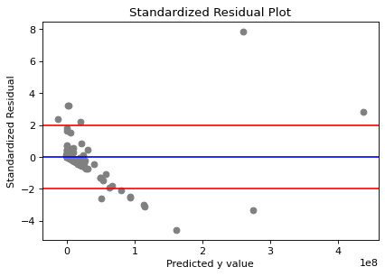

```python
Homoscedasticity(data, "Predicted y value")
```

```python
Randomness(SD)
```

```
Randomness Test using Runs Test
 - H0: Randomness exists.
 - H1: Randomness does not exist

runs =  83
n1 =  87
n2 =  85

runs_exp =  86.98837209302326
stan_dev =  6.5373473898371435
z =  -0.6100902790057506
pval_z =  0.5418020057487212

Since p-value > 0.05, we do not reject H0 and we may conclude randomness exists.
```

### outliers

```python
Outlier(SD)
```

```
Outliers by SD =

0      7.848549
1      2.837301
2     -3.330293
3      2.225650
5      3.232967
11     2.355111
21    -2.982963
36    -3.110849
37    -2.618268
79     3.213364
95    -2.548883
105   -4.565045
157   -2.492680
164   -2.108644
Name: SD, dtype: float64

Sample [1, 2, 3, 4, 6, 12, 22, 37, 38, 80, 96, 106, 158, 165] are outliers.
```

### influential observations

```python
X_data_ar = np.array([df_multi['Facebook_likes'], df_multi['Twitter_mentions'], df_multi['Google_pluses'], df_multi['LinkedIn_mentions']])
X_data_T = X_data_ar.T
X_data = pd.DataFrame(X_data_T, columns = ['Facebook_likes', 'Twitter_mentions', 'Google_pluses', 'LinkedIn_mentions'])
X_data2 = sm.add_constant(X_data)
X = X_data2
H_b = np.dot(X, np.linalg.solve(np.dot(X.T, X), X.T))
df_multi['hii'] = np.diagonal(H_b)
k = result.df_model
n = len(df_multi['hii'])
h_level = 3 * (k+1) / n
print("h_level = ", h_level)
print(" \n")
filter = (df_multi['hii'] > h_level )
print("Influential Observations by hi = \n")
print(df_multi['hii'].loc[filter])
```

```
h_level =  0.08771929824561403


Influential Observations by hi =

1      0.196359
2      0.543798
3      0.998803
22     0.790549
23     0.143942
34     0.200914
267    0.826352
Name: hii, dtype: float64
```

### cook

```python
s2_e = result.mse_resid
k = result.df_model
y_a = data[:, 1]
y_f = data[:, 2]
h_i = df_multi['hii']
CD_arr = np.square(y_a - y_f) / s2_e / (k - 1) * h_i / np.square(1 - h_i)
CD = np.array(CD_arr)
df1_cd = pd.DataFrame(CD,columns = ['CD'])
display(df1_cd.head())
filter = (df1_cd['CD'] > 1 )
print("Influential Observations by Cook's Distances = \n")
print(df1_cd['CD'].loc[filter])
```

|  | CD |
| --- | --- |
| 0 | 5.017021 |
| 1 | 3.198676 |
| 2 | 3085.120759 |
| 3 | 0.010285 |
| 4 | 0.000160 |

```
Influential Observations by Cook's Distances =

0        5.017021
1        3.198676
2     3085.120759
10       4.618485
37      10.874343
Name: CD, dtype: float64
```

### Assess the fitted model

#### f-test

$H_0$: $\beta_i$ = 0

$H_1$: At least one $\beta_i$ $\neq$ 0

```python
f_res = result.fvalue
MSE = result.mse_resid
df_model = result.df_model
df_error = result.df_resid
MSR = f_res * MSE
SSR = MSR * df_model
print("SSR = ", SSR, "df = ", df_model, "MSR = ", MSR)
print("SSE = ", MSE * df_error, "df = ", df_error, "MSE = ", MSE)
print("F = ", MSR / MSE)
A = np.identity(len(result.params))
A = A[1:,:]
print(result.f_test(A))
```

```
SSR =  4.0366119134210874e+17 df =  4.0 MSR =  1.0091529783552718e+17
SSE =  2.1767308326573254e+17 df =  166.0 MSE =  1311283634130919.0
F =  76.95916825989438
<F test: F=array([[76.95916826]]), p=8.541649218199939e-37, df_denom=166, df_num=4>
```

pvalue = 8.541649218161541e-37 < 0.05, we can reject H0. There is sufficient evidence to reject the null hypothesis in favor of the alternative hypothesis. At least one of the $\beta_i$ is not equal to zero. Thus, at least one independent variable is related to y. This regression model is valid.

#### std err estimate

```python
print("standard error = ", result.mse_resid ** 0.5)

print("mean of y", df_multi['Avg_Daily_Visitors'].mean())
print("std of y", df_multi['Avg_Daily_Visitors'].std())
```

```
standard error =  36211650.53033235
mean of y 15486356.736842105
std of y 60455830.965202905
```

The standard err of estimate = 36211650.53033235, mean of y = 15486356.736842105. It appears that the standard error of estimate is quite large.

#### r^2

```python
SSR = result.ssr
R2 = result.rsquared
print("SSR = ", SSR)
print("R2 = ", R2)
```

```
SSR =  2.1767308326573254e+17
R2 =  0.6496683151704159
```

#### testing of the coefficients

$H_0$: $\beta_i$ = 0

$H_1$: $\beta_i \neq$ 0

### interpretation

Estimated model: y = -8.559e+05 + 21.9098 Google_pluses + 46.1482 Facebook_likes + -1.1468 Twitter_mentions + 240.9073 LinkedIn_mentions

X1: when Facebook_likes increases by 1 unit, Y will increase by 46.1482 units

X2: when Google_pluses increases by 1 unit, Y will increase by 21.9098 units

Since p-value = 8.54e-37 < alpha = 0.05, we can reject H0. There is enough evidence to conclude that the model is valid with r-squared = 0.650 and Adj. R-squared = 0.641.

從結論來看，我們可以在適當情況提供以下的建議:  
1.在有限的社群宣傳資金下，在多項平台投放比起單一平台投注大量廣告效果較佳  
2.Facebook與Google社群的提及與流量的相關性較大，可能平台包含較新、流量較大資訊或者對平台有較大影響力  
3.網站流量分析需要更多常態性與多元性，包含中小型網站與除了搜尋引擎及社群媒體的資料會對結果較有合理解釋性